# Complementary Chromatic Acclimation in Picocyanobacteria; Quantitation of Benefits

Sylwia Sliwinska-Wilczewska<sup>1,2</sup>, Naaman Oman<sup>1</sup>, Mireille Savoie<sup>1</sup>, Maximilian Berthold<sup>1</sup>, and Douglas A. Campbell<sup>1</sup>

<sup>1</sup> Department of Biology, Mount Allison University, 53 York St., Sackville NB, Canada, E4L 1C9  
<sup>2</sup> Institute of Oceanography, University of Gdansk, 46 Pilsudskiego St, P81-378, Gdynia, Poland

```r
FiguresFP <- file.path("SySl_CCA_manuscript_files", "figure-html")
```

# 1. Introduction

If we can get growth return upon PSII ETR and/or JVPSII and the quantitative benefit of CCA then we can send this to… J. Phyco ISME?? Photosynthesis Research

Think about target journals… ….

Tasks:

1. Extract slopes from O2 data; tricky b/c we need to set boundaries for light steps
2. Replot O2 slopes vs. PAR
3. Plot JVPSII and/or PSII ETR vs. PAR
4. Generate representative spectral figures from OLIS Deconvolute pigment peaks from OLIS to ‘show’ CCA
5. Figure out how to ‘pool’ estimates across runs to generate central estimates; possibly simply take growth rates as ‘points’ and average; state in Caption that SE on individual determinations was <= XX or XX% of mean?
6. Figure out how to plot growth return on JVPSII and on O2 evln; is it consistent or not; does CCA involve changes in e:CO2 (CO2 taken as net O2…..

No obvious experimental work ‘missing.’ Most of the needed data transforms overlap with other manuscript Which could be merged with this manuscript…?

So Doug suggests initial focus on CCA manuscript

Considering figuring out how to do separate bibliographies for packages vs. for scientific citations?

Sylwia: Write Introduction; survey of relevant papers; why we did what we did? Sylwia: Write draft of Materials & Methods; extensive…

Results: Figures + Captions (text is ‘short’)

Discussion…

# 2. Material and Methods

Strains change their PE:PC ratio depending upon growth light color, as shown by OLIS spectra

Laboratory work - status: completed

- 2 strains of picocyanobacteria: BA77G, BA127R
- 2 light intensities (Par_ue): 60, 300 µE
- 2 light color (WL): G530, R660
- 1 photoperiod: 12:12
- = 8 combinations
- 3 independent measurements (runs) on color MultiCulti
- Tracking growth (number of cells – N, growth rate – µ) with color MultiCulti (for every 5 minutes) and using linear regression models based on cell suspension density (N mL−1) (PAMAS counter/flow cytometer) and optical density (OD) at 680 & 720 & 750 nm measured from the same samples (ClarioStar spectrophotometer)
- Additionally, tracking the number of cells using PicoDevice (repeatedly in the exponential growth phase)
- Tracking photosynthetic performance using Solisense and Optode at Ex445, Ex470, Ex505, Ex535, Ex590 (repeatedly in the exponential growth phase)
- Sub set of data at low to moderate light could be used for calibrations
- Tracking Chl a with Turner (repeatedly in the exponential growth phase)
- Tracking whole cell pigmentation profiles based on Olis spectrophotometer (repeatedly in the exponential growth phase)

Analysis of the results - status: in progress Article completion date: ~February-March 2023

- OLIS:

  Absorbance measurements on intact cells in suspension were conducted in an Olis-modernized Cary 14 UV/Vis/NIR with Integrating Sphere upgrade spectrophotometer (On-Line Instrument Systems, Inc., Bogart, GA, USA) according to the method described by Blake and Griff (2012) with modifications. In an experiment, identical 8 mL solutions that contained f/2 medium, were added to both the sample and reference observation cavities of the spectrophotometer. After recording a baseline from 375 to 710 nm, 4 mL were withdrawn from the sample cavity and replaced with 4 mL of the cell suspension of tested picocyanobacteria. The pathlength corrected absorbance per cm was performed by determining the Javorfi coefficients as described in the equipment manual.

Blake, R. C., & Griff, M. N. (2012). In situ spectroscopy on intact Leptospirillum ferrooxidans reveals that reduced cytochrome 579 is an obligatory intermediate in the aerobic iron respiratory chain. Front Microbiol. 3, 136.

## Statistical analysis

We used R (Team, 2019) running under RStudio (Team, 2015), using packages “tidyverse” (Wickham, 2022), “glue” (Hester and Bryan, 2022), “googlesheets4” (Bryan, 2022), “kableExtra” (Zhu, 2021).

# 3. Results

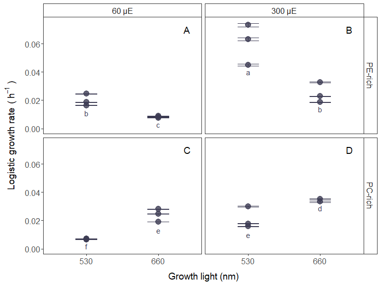

Figure 1: Logistic growth rate (tracked as chlorophyll proxy of OD<sub>680</sub>-OD<sub>720</sub>) of culture of PE-rich (A,B; BA127R) or PC-rich (C,D; BA77G) *Synechococcus* sp. grown under green light (Growth light: 530 nm) or red light (Growth light: 660 nm) at: 60 µmol photons m<sup>-2</sup>s<sup>-1</sup> (A,C) or 300 µmol photons m<sup>-2</sup>s<sup>-1</sup> (B,D). Error bars display the standard error of the logistic growth rate estimated of each culture replica (*n* = 3). Different lowercase letters indicate significant differences between the means of the growth across light level and colour for a given strain (*p* < 0.05, two-way (factorial) ANOVA; Tukey’s HSD test).

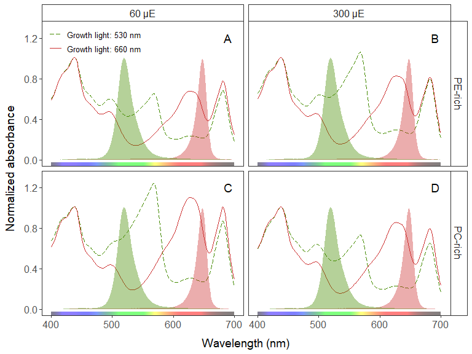

Figure 2: Representative whole-cell absorbance spectra normalized at 440 nm of culture of PE-rich (A,B; BA127R) or PC-rich (C,D; BA77G) *Synechococcus* sp. grown under green light (Growth light: 530 nm; green and longdash line) or red light (Growth light: 660 nm; red and solid line) at: 60 µmol photons m<sup>-2</sup>s<sup>-1</sup> (A,C) or 300 µmol photons m<sup>-2</sup>s<sup>-1</sup> (B,D) together with emission spectra of the green (530 nm; green area) or red (660 nm; red area) LED lamps used for growth of the *Synechococcus* sp. cultures.

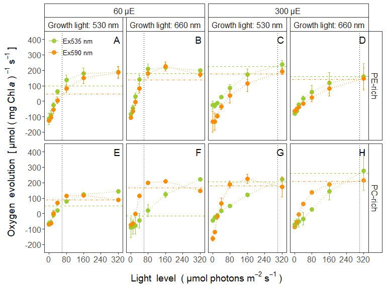

Figure 3: Light response curves for oxygen evolution measured under Ex535 nm (green) or Ex590 nm (orange) of culture of PE-rich (A-D; BA127R) or PC-rich (E-H; BA77G) *Synechococcus* sp. grown under green light (A,C,E,G; Growth light: 530 nm) or red light (B,D,F,H; Growth light: 660 nm) at 60 µmol photons m<sup>-2</sup>s<sup>-1</sup> (A,B,E,F) or 300 µmol photons m<sup>-2</sup>s<sup>-1</sup> (C,D,G,H). The dotted and black vertical lines indicate the light level at which the cultures of *Synechococcus* sp. were grown. The horizontal lines indicate the oxygen evolution value obtained under Ex535 nm (dashed green) or Ex590 nm (dotdash orange) at the light level in which the individual cultures were grown. Data are reported the means ± standard deviations.

# Supplementary material

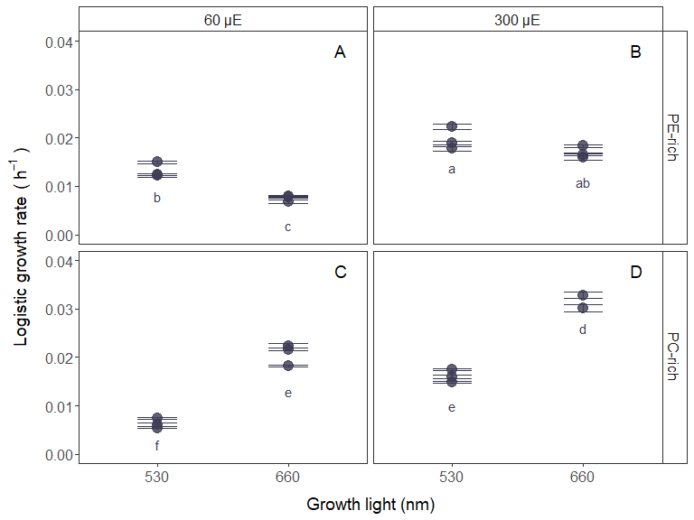

Figure 4: Logistic growth rate (using cell-scatter proxy OD<sub>720</sub>) of culture of PE-rich (A,B; BA127R) or PC-rich (C,D; BA77G) *Synechococcus* sp. grown under green light (Growth light: 530 nm) or red light (Growth light: 660 nm) at: 60 µmol photons m<sup>-2</sup>s<sup>-1</sup> (A,C) or 300 µmol photons m<sup>-2</sup>s<sup>-1</sup> (B,D). Error bars display the standard error of the logistic growth rate estimated of each culture replica (*n* = 3). Different lowercase letters indicate significant differences between the means of the growth across light level and colour for a given strain (*p* < 0.05, two-way (factorial) ANOVA; Tukey’s HSD test).

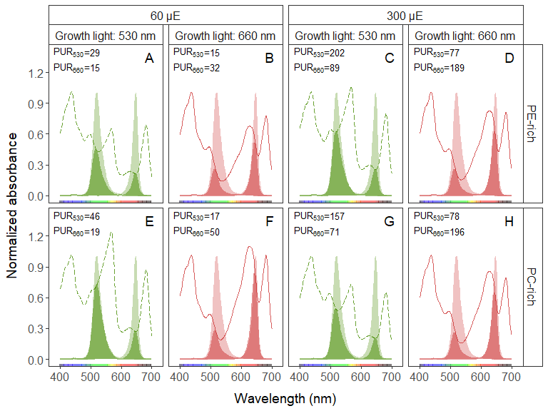

Figure 5: Representative whole-cell absorbance spectra normalized at 440 nm of culture of PE-rich (A-D; BA127R) or PC-rich (E-H; BA77G) *Synechococcus* sp. grown under green light (Growth light: 530 nm; green and longdash line; A,C,E,G) or red light (Growth light: 660 nm; red and solid line; B,D,F,H) at: 60 µmol photons m<sup>-2</sup>s<sup>-1</sup> (A,B,E,F) or 300 µmol photons m<sup>-2</sup>s<sup>-1</sup> (C,D,G,H) together with emission spectra of the green (530 nm; green light area) or red (660 nm; red light area) LED lamps used for growth of the *Synechococcus* sp. cultures as well as calculated PUR value (green and red dark area) for a given strain and growth condition.

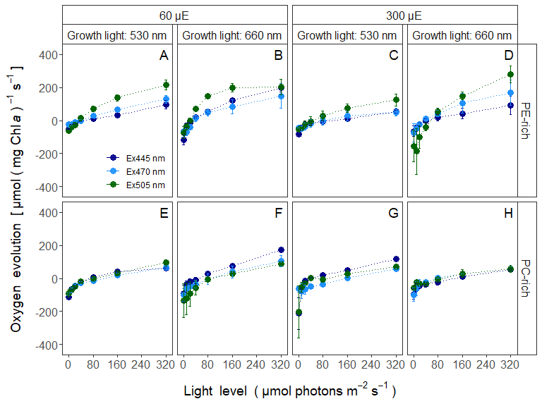

Figure 6: Light response curves for oxygen evolution measured under Ex445 nm (dark blue), Ex470 nm (light blue), Ex505 nm dark green) of culture of PE-rich (A-D; BA127R) or PC-rich (E-H; BA77G) *Synechococcus* sp. grown under green light (A,C,E,G; Growth light: 530 nm) or red light (B,D,F,H; Growth light: 660 nm) at 60 µmol photons m<sup>-2</sup>s<sup>-1</sup> (A,B,E,F) or 300 µmol photons m<sup>-2</sup>s<sup>-1</sup> (C,D,G,H). Data are reported the means ± standard deviations.

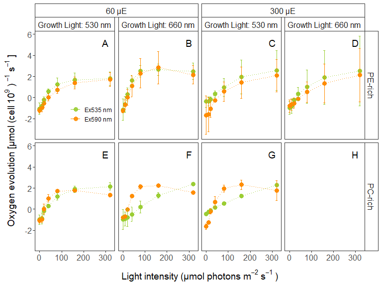

# Additional plots

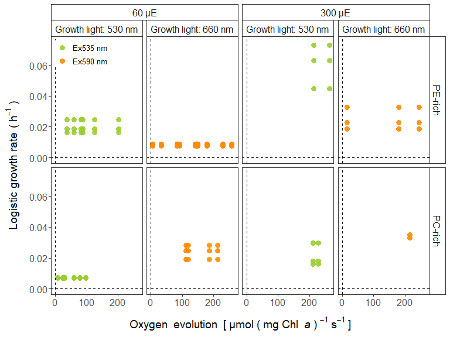

Figure 8: Growth rate (Delta) vs. Oxygen evolution

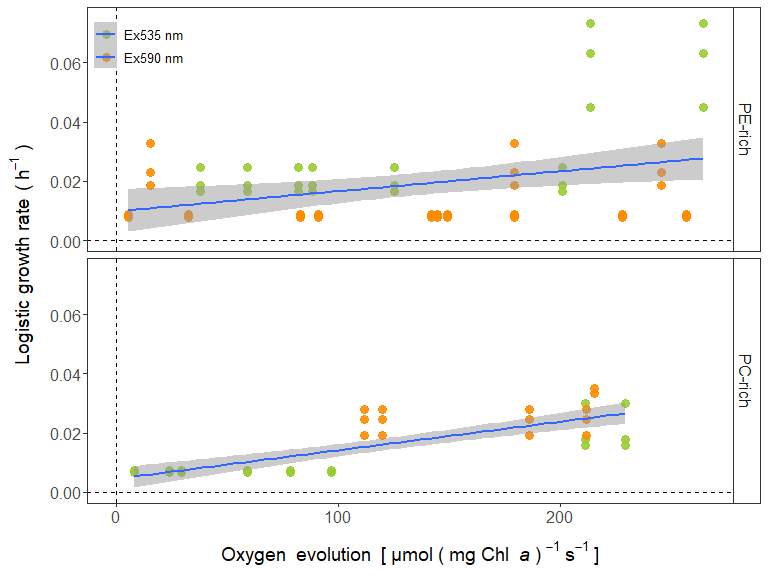

Figure 9: Growth rate (Delta) vs. Oxygen evolution

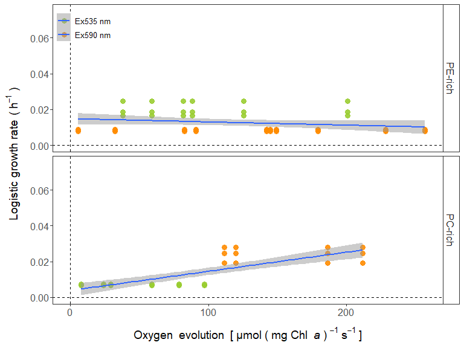

Figure 10: Growth rate (Delta) vs. Oxygen evolution

# Comments

- Comments and suggestions (07.2022):

Think about faceting. Could facet by growth light to bring out interaction; does high growth light allow strain to over come ‘wrong’ colour?

Think about how to pool data from runs and possibly generate a common error bar?

Possible: Make symbol size proportional to SE of run fit and then calculate an overall SE across all replicates taking each replicate as a point OR in caption state SE on individual determinations of growth rates were always < …. absolute or proportional

Strain without PE is far more ‘fixed’ in response to colour; strongly favours 660 Strain with PE BA127R appears more able to accommodate changing colour from green to red…

Generally set Y axis to start at 0

Presenting Chl or PC or PE per cell after a fixed interval is fine as long as there is some ‘reason’ for the interval. Presenting absolute Chl mL-1 after fixed interval needs to be presented careful and is only useful in terms of potential to dominate habitat within a reasonable period….

Chl cell-1 could be usefully compared to measures of PSII cell-1 if we can get them from the calibrations…

(Conceptually Doug would prefer PE/PC unless the field generally uses PC/PE - done)

Basis for ratio: ug PC/ug PE? Peak PC/Peak PE…

From OLIS could be peak height or peak area after deconvolution…

Extract OLIS data to confirm/alter interpretations from filter data…

Extract slopes of O2 umol L-1 s-1 from O2 data Replot slopes vs. incident light

Compare O2 slopes to PSII ETR and/or JVPSII slopes to get O2 : e-… is achieved conversion of PSII ETR to O2 similar or variable?

Mechanistically always 1 O2 : 4 e- from PSII, but re-consumption of e- and O2 can alter measured ratio. Compare growth rates per PSII ETR and growth rates per O2; does PSII ETR limit achieved growth rate or do intervening processes alter conversion of net reductant (complement of measure O2 evolution) to growth

xxx

- Comments and suggestions (21.11.2022):

Tubes under green or red were inoculated from white light precultures so first days in MultiCulti spectra will be changing

Figure Raw Growth. Formatted example of MultiCulti output (could be a ‘Supplemental’).

Figure Growth. Multipanel figure of growth rates somehow? Depending upon order of coverage could be first or last? But probably, first. This is probably a bar and whiskers plot with a bar/whiskers for each growth combination of strain, colour and light level How to organize? Could emphasize strain to strain contrast BA127 R cvs. BA77G under 60 and Green Then BA127 R cvs. BA77G under 300 and Green …. Or, could think of some sort of scatter plot heat map? Heat map for each strain each heat map with 4 cells for colour and light level?

Decide how to estimate growth rates - Do not number figures until we are finished. Name them. We may need a panel Letter on each ‘facet’ or maybe not depending upon journal. There is a way (‘CowPlot?’) or other to add letters to each panel. We will use the code to add the ‘variable’ name as well as the variable ‘value’ to the facet labels (later)

- Think of Y axis scaling; why did ggplot scale to 0.2 A when maximum value is only ~0.08? Are there missing points? #Fixed
- Consider whether to normalize spectra to common wavelength absorbance or not? Consider normalization to A680 or A440 #Done - at 440

To emphasize CCA changes in PC and PE, consider overlay of spectra from green and red light. What is the peak at 480 nm? phycourobilin? carotenoids Also: lab tests with Mireille; is there something wrong with the baseline correction b/c spectral peaks seem to be asymmetric; instead of gaussian

To normalize, probably something like mutate(Anorm = A/A[nm == 440] To lower noise, we might normalize to something like the mean of A 438-442…

Why is the plateau reached at 0.8, across growth conditions?

Figure “OlisSpectra” shows: -both strains change PC/PE ratio depending upon growth light colour (show CCA of some form) -both strains show a 480 nm peak which may increase under high light? -both strains show change in the PB to Chl ratio under low to high light? -estimate peaks normalized to scatter? or content per cell? -consider deconvolutions (code draft exists but not yet run) -consider plotting metric of light capture capacity vs. growth rate if we estimate cellular photosynthetic absorbance X PAR can we predict growth rate? -does CCA alter the growth return on incident light -we can estimate ‘in silico’ b/c you have the whole cell spectra for red light, and the growth rate for red light, and vice versa for green light so we can take whole cell absorbance under red light and multiply by hypothetical incident green light

Add r overlay incident light spectra on top of absorbance spectra?

Mix of ‘techincal’ measures and measures from separate tubes? Debate what is a ‘replicate’; each panel contains measures from at least 2 tubes, usually 3; some ‘replicates’ are remeasurements of subsamples from the same tube the next day All measures taken from actively growth cultures (exponential…); and we have high resolution growth curves

- What about other growth metrics; Turner chlorophyll? PICO cell counts? ClarioStar absorbance
- Ask Doug how he calculated the light response curves of photochemical and non-photochemical quenching for cyanobacteria

xxx

Final Figure captions?

Fig. 1. Representative whole-cell absorbance spectra of PE-rich (BA127R) and PC-rich (BA77G) Synechococcus sp. cultures grown under red (WL: 660) or green (WL: 530) light at 60 µmol photons m-2s-1 and 300 µmol photons m-2s-1.

Fig. 2. Light response curves for oxygen evolution measured at Ex445 (—), Ex470 (—), Ex505 (—), Ex535 (—), Ex590 (—) (nm) of PE-rich (A) and PC-rich (B) Synechococcus sp. cultures grown under red light (a) and green light (b). Oxygen evolution at low light intensities for Synechococcus sp. cultures measured under the light quality used for their growth, red (—) or green (—) (c). # at 60 µmol photons m-2s-1 (a) and 300 µmol photons m-2s-1 (b)?

Fig. 3. Light response curves of photochemical quenching for PE-rich (A) and PC-rich (B) Synechococcus sp. cultures measured under red (—) or green (—) light. #(or measured at Ex445 (—), Ex470 (—), Ex505 (—), Ex535 (—), Ex590 (—) (nm)). The dashed vertical lines mark the growth light intensity (60 µmol photons m-2s-1 and 300 µmol photons m-2s-1). Synechococcus sp. cultures grown under red (a) and green (b) light.

Fig. 4. Light response curves of non-photochemical quenching for PE-rich (A) and PC-rich (B) Synechococcus sp. cultures measured under red (—) or green (—) light. #(or measured at Ex445 (—), Ex470 (—), Ex505 (—), Ex535 (—), Ex590 (—) (nm)). The dashed vertical lines mark the growth light intensity (60 µmol photons m-2s-1 and 300 µmol photons m-2s-1). Synechococcus sp. cultures grown under red (a) and green (b) light.

Fig. 5. PS I fluorescence emission at 77 K correlates with nonphotochemical quenching of in vivo PS II fluorescence for PE-rich (A) and PC-rich (B) Synechococcus sp. cultures. PS I fluorescence excited by phycobilisome absorbance (⃝ ) (590 nm) or by chlorophyll absorbance ( ⃞ ) (445 nm), plotted versus nonphotochemical quenching of in vivo PS II fluorescence (a). Ratio of (PS I fluorescence excited by phycobilisome absorbance)/(PS I fluorescence excited by chlorophyll absorbance), plotted versus non-photochemical quenching of in vivo PS II fluorescence (b). Synechococcus sp. cultures grown under red ( ⃞ ) and green (⃝ ) light.

# References

Bryan, J., 2022. googlesheets4: Access google sheets using the sheets API V4.

Hester, J., Bryan, J., 2022. Glue: Interpreted string literals.

Team, R.C., 2019. R: A Language and Environment for Statistical Computing. R Fundation for Statistical Computing, Vienna, Austria.

Team, Rs., 2015. RStudio: Integrated Development Environment for R. RStudio, Inc., Boston, MA.

Wickham, H., 2022. Tidyverse: Easily install and load the tidyverse.

Zhu, H., 2021. kableExtra: Construct complex table with kable and pipe syntax.